# Promotions Within the Public Service of Canada by Designated Group and Occupational Category

### visualization of the data

1. Drawing a bar graph showing the different distributions of employees categories across regions of work
1. Converted the data to numerical data
2. Created a bar graph

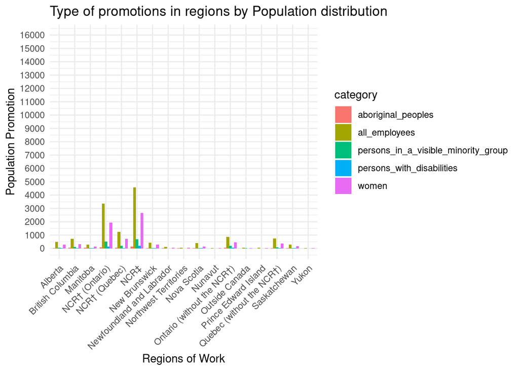

```r
subset_data <- subset_data %>%
  mutate_at(vars(all_employees, women, persons_in_a_visible_minority_group, persons_with_disabilities, aboriginal_peoples),
            as.numeric)

subset_data_long <- subset_data %>%
  gather(key = "category", value = "value", -region_of_work)

ggplot(subset_data_long, aes(x = region_of_work, y = value, fill = category)) +
  geom_bar(stat = "identity", position = position_dodge(width = 0.8)) +
  labs(title = "Type of promotions in regions by Population distribution",
       y = "Population Promotion", x = "Regions of Work") +
  theme_minimal() +
  theme(axis.text.x = element_text(angle = 45, hjust = 1)) +
  scale_y_continuous(limits = c(0, 16000), breaks = seq(0, 16000, by = 1000))
```

from the bar graph above you can see:

- women have an averagely distributed rate of promotion
1. distribution of employment across regions

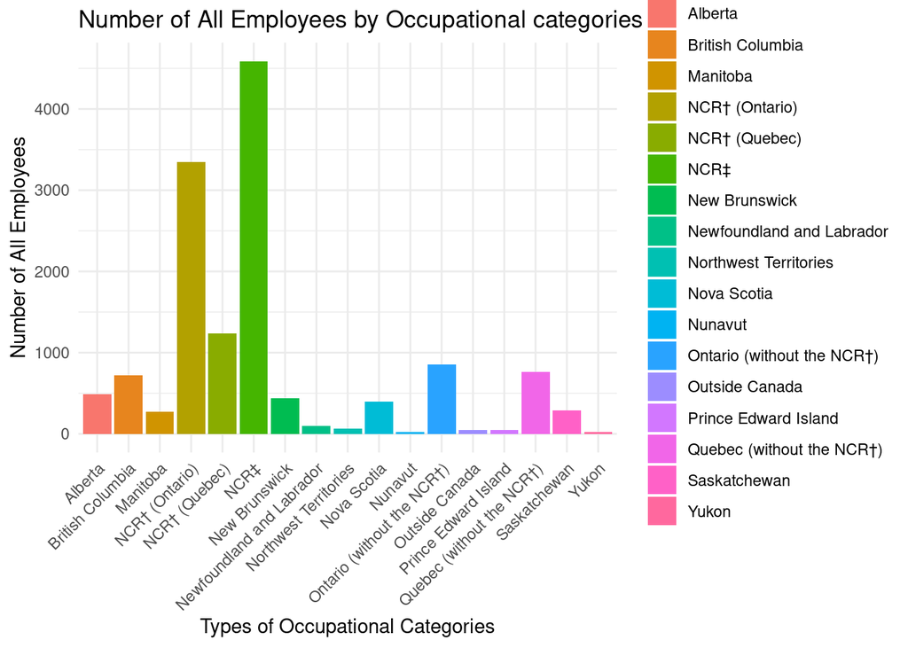

```r
ggplot(subset_data, aes(x = region_of_work, y = all_employees, fill = region_of_work)) +
  geom_bar(stat = "identity") +
  labs(title = "Number of All Employees by Occupational categories",
       x = "Types of Occupational Categories",
       y = "Number of All Employees") +
  theme_minimal() +
  theme(axis.text.x = element_text(angle = 45, hjust = 1))
```

from the bar graph above you can deduce:

- NCR posts a high record of promotions to its employees
- low rate of promotions in Yukon
2. Scatter plot for distribution of women across regions of work

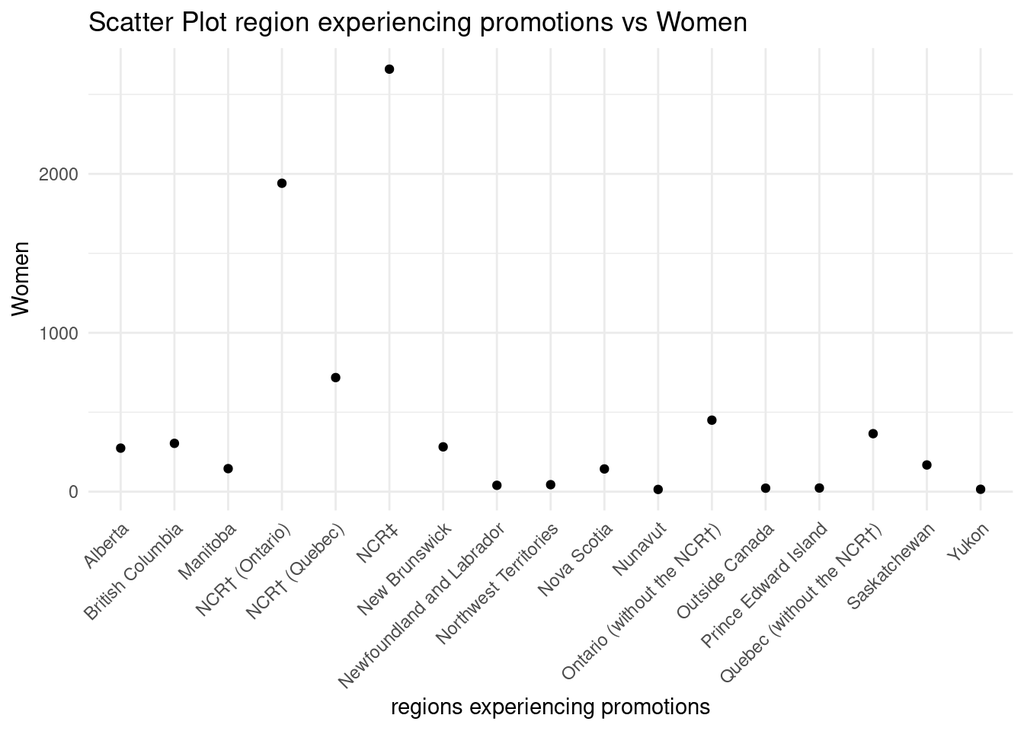

```r
ggplot(subset_data, aes(x = region_of_work, y = women)) +
  geom_point() +
  labs(title = "Scatter Plot region experiencing promotions vs Women",
       x = "regions experiencing promotions",
       y = "Women") +
  theme_minimal() + theme(axis.text.x = element_text(angle = 45, hjust = 1))
```

from the scatter plot above we can deduce:

- NCR still poses as a high employer for women and yukon poses the opposite - lowest employement
3. summary of how the employees are spread out

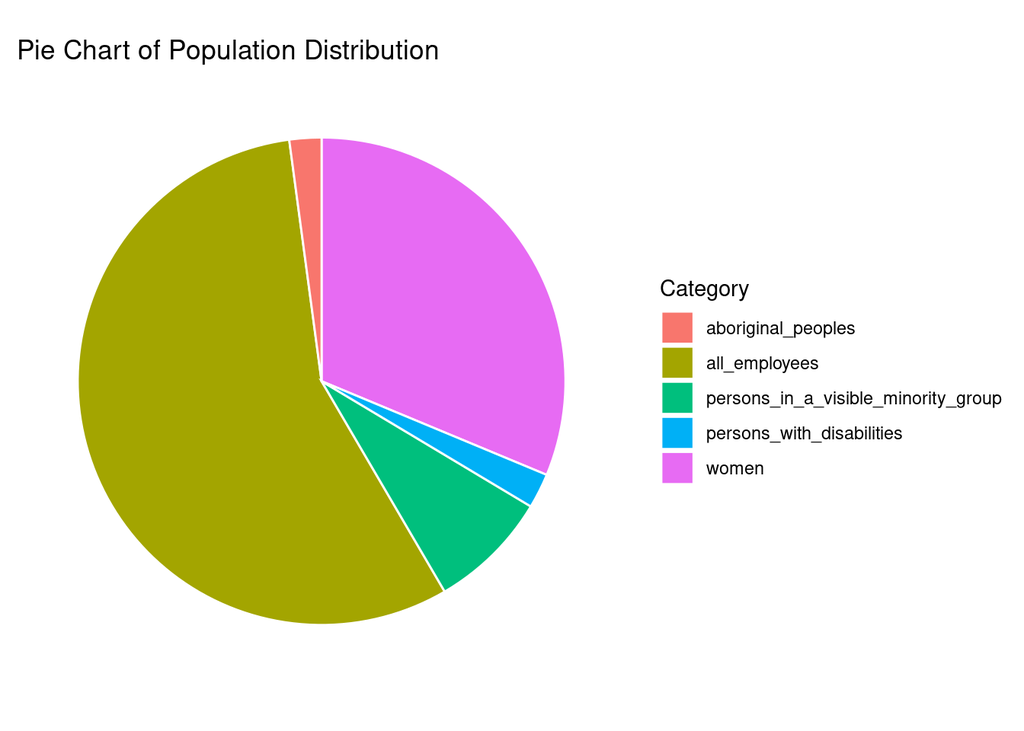

```r
summary_data <- subset_data %>%
  summarise(
    all_employees = sum(all_employees),
    women = sum(women),
    persons_in_a_visible_minority_group = sum(persons_in_a_visible_minority_group),
    persons_with_disabilities = sum(persons_with_disabilities),
    aboriginal_peoples = sum(aboriginal_peoples)
  )
summary_data_long <- gather(summary_data, key = "category", value = "value")
ggplot(summary_data_long, aes(x = "", y = value, fill = category)) +
  geom_bar(stat = "identity", width = 1, color = "white") +
  coord_polar("y") +
  labs(title = "Pie Chart of Population Distribution",
       fill = "Category") +
  theme_minimal() +
  theme(axis.text = element_blank(),
        axis.title = element_blank(),
        panel.grid = element_blank())
```

from the pie chart above we can deduce:

- women are the second most employed category
- Aboriginal people and person with disabilities have a few representation in the job industry